# Estimating growth increment, productivity, and vital rates with ProdVital

John L. Godlee

2023-08-10

# Setup

```r
# Packages
library(dplyr)
library(ProdVital)
library(ggplot2)
```

Load the example dataset included in `{ProdVital}`:

```r
data(bicuar)
```

`bicuar` is a dataframe of stem data from two plots in Bicuar National Park, southwest Angola, measured across three censuses. Censuses were conducted in 2019, 2021 and 2023. The original data is real, but it has been adjusted to better illustrate the functionality of `{ProdVital}`. Each row is a stem measurement (individual) in a given census.

- `plot_id` - ID of the plot
- `census_date` - Census date of measurement
- `stem_id` - ID value grouping measurements into stems (individuals)
- `stem_status` - Vital status of individual: alive, resprouting, dead
- `diam` - Stem diameter (cm)
- `agb` - Estimated aboveground biomass (Mg)

# Prepare the stem data

Stems may be missing from a particular census, despite being measured in censuses before and after. Stem timelines should not have gaps, otherwise you will get unrealistic estimates of recruitment, mortality, and biomass turnover using the functions in `{ProdVital}`. We need to create these rows so we can fill them with estimated values. We can do this using the `indFill()` function:

```r
# Generate missing rows
missing_records <- indFill(bicuar, d = unique(bicuar$census_date),
    group = c("plot_id", "stem_id"), census = "census_date")

# All the new records should be in the middle census
stopifnot(all(missing_records$census_date == 2021))

# Add the missing rows to the stem data
bicuar_pad <- bind_rows(bicuar, missing_records)
```

Sometimes, a stem will appear to have died only to resurrect at a later date. Stems might also be missing stem status values. We can try to fix these issues using the `mortFill()` function.

```r
# Adjust mortality status values
bicuar_pad$mort_status <- case_when(bicuar_pad$stem_status ==
    "a" ~ 1, bicuar_pad$stem_status %in% c("r", "d") ~ 0, TRUE ~
    NA_real_)

# Impute mortality status
bicuar_pad$status_imput <- mortFill(bicuar_pad, group = c("plot_id",
    "stem_id"), census = "census_date", status = "mort_status")
```

Now that the stem status values have been fixed, we should remove measurements of dead stems. The functions in `{ProdVital}` assume that the stem data only contain measurements from living stems. Measurements from dead stems should be excluded from the stem data. The absence of a stem from a particular census after it was initially measured implies that the stem was dead during that census. Similarly the absence of a stem from a particular census before it was initially measured implies that the stem had not yet recruited.

```r
bicuar_alive <- bicuar_pad %>%
    filter(status_imput == 1)
```

Stem diameter measurements might be missing. These values should be imputed if you are calculating plot-level productivity, otherwise you will get unrealistic estimates of growth and loss. A simple way to impute missing diameter values is to take the mean of measured diameters before and after the missing diameter:

```r
bicuar_clean <- bicuar_alive %>%
    group_by(plot_id, stem_id) %>%
    mutate(diam = ifelse(is.na(diam), mean(diam, na.rm = TRUE),
        diam), agb = ifelse(is.na(agb), mean(agb, na.rm = TRUE),
        agb)) %>%
    filter(!is.na(diam))

stopifnot(all(!is.na(bicuar_clean$diam)))
```

It is important to understand that this naive approach doesn’t consider that some diameter measurements may contain errors, what should happen if the missing value is at the start or end of the stem timeline, or what should happen if there are multiple consecutive missing values. In these cases, more complex approaches will be required to impute missing diameter values.

# Identify stem fate

Using the `obsID()` function, it is possible to identify the fate of individual stems within a given census interval. **Recruits** are stems which were not present in the initial census, but are present in the final census. **Survivors** are stems which are present in both the initial and final census. **Deaths** are stems which are present in the initial census but not in the final census:

```r
bicuar_clean$plot_stem <- paste(bicuar_clean$plot_id, bicuar_clean$stem_id,
    sep = ":")

obs1 <- obsID(bicuar_clean, t0 = "2019", tT = "2021", type = c("rec",
    "sur", "mor"), group = "plot_stem", census = "census_date")

lapply(obs1, head)
```

```
## $rec
##       plot_stem
## 16   ABG_15:102
## 195  ABG_15:133
## 1858  ABG_15:59
## 2165  ABG_5:679
## 2173  ABG_5:680
## 2175  ABG_5:681
##
## $sur
##     plot_stem
## 1     ABG_5:1
## 4    ABG_5:10
## 7   ABG_5:100
## 10 ABG_15:101
## 12  ABG_5:101
## 17  ABG_5:102
##
## $mor
##      plot_stem
## 89   ABG_5:114
## 156 ABG_15:126
## 177   ABG_5:13
## 230  ABG_5:139
## 248 ABG_15:142
## 249  ABG_5:142
```

Note that `plot_stem` was created to provide single ID column, but this is also valid:

```r
obs2 <- obsID(bicuar_clean, t0 = "2019", tT = "2021", type = c("rec",
    "sur", "mor"), group = c("plot_id", "stem_id"), census = "census_date")

lapply(obs2, head)
```

```
## $rec
##      plot_id stem_id
## 16    ABG_15     102
## 195   ABG_15     133
## 1858  ABG_15      59
## 2165   ABG_5     679
## 2173   ABG_5     680
## 2175   ABG_5     681
##
## $sur
##    plot_id stem_id
## 1    ABG_5       1
## 4    ABG_5      10
## 7    ABG_5     100
## 10  ABG_15     101
## 12   ABG_5     101
## 17   ABG_5     102
##
## $mor
##     plot_id stem_id
## 89    ABG_5     114
## 156  ABG_15     126
## 177   ABG_5      13
## 230   ABG_5     139
## 248  ABG_15     142
## 249   ABG_5     142
```

`obsID()` serves as a building block in many other functions in `{ProdVital}`, like `prodKohyama()`, `vitalKohyama()` and `obsSurGrowth()`.

# Observed stem growth, recruitment growth, and mortality loss

The `obsSurGrowth()` function can calculate the growth increment of all stems which survived between two censuses. The argument `w` gives the column used to calculate growth. The function returns a named vector of stem growth increments between the two census dates. The names refer to the `group` ID column(s) used to define individuals.

```r
obsSurGrowth(bicuar_clean, t0 = "2019", tT = "2021", w = "diam",
    group = c("plot_id", "stem_id"), census = "census_date")
```

```
##    ABG_5.1   ABG_5.10  ABG_5.100 ABG_15.101  ABG_5.101  ABG_5.102 ABG_15.103
##      0.400      1.000      0.000      0.200     -0.100     -0.100     -0.200
##  ABG_5.103 ABG_15.104  ABG_5.104 ABG_15.105  ABG_5.105 ABG_15.106  ABG_5.106
##     -0.800     -0.700     -0.400      0.000     -0.800      0.200     -0.500
## ABG_15.107  ABG_5.107 ABG_15.108  ABG_5.108 ABG_15.109  ABG_5.109   ABG_5.11
##      0.500     -0.500      0.000     -0.100     10.700     -2.900      0.200
## ABG_15.110  ABG_5.110 ABG_15.111  ABG_5.111 ABG_15.112  ABG_5.112 ABG_15.113
##     -0.500     -0.500      0.400      0.600      0.400      1.300      0.500
##  ABG_5.113 ABG_15.114 ABG_15.115  ABG_5.115 ABG_15.116  ABG_5.116 ABG_15.117
##      0.000      0.000     -0.100     -0.300      0.000     -0.100      0.000
##  ABG_5.117 ABG_15.118  ABG_5.118 ABG_15.119  ABG_5.119   ABG_5.12 ABG_15.120
##      0.200     -0.200     -0.400      0.200      2.900     -0.200      4.200
##  ABG_5.120 ABG_15.121  ABG_5.121 ABG_15.122  ABG_5.122 ABG_15.123  ABG_5.123
##     -0.200      0.500      0.000      0.800      0.700     -0.100     -1.300
## ABG_15.124  ABG_5.124 ABG_15.125  ABG_5.125  ABG_5.126 ABG_15.127  ABG_5.127
##     -0.800     -0.900      0.000     -0.200     -0.600     -0.600      1.300
## ABG_15.128  ABG_5.128 ABG_15.129  ABG_5.129 ABG_15.130  ABG_5.130 ABG_15.131
##      0.000     -0.300      2.043      0.200      0.500      0.600      0.000
##  ABG_5.131 ABG_15.132  ABG_5.132  ABG_5.133 ABG_15.134  ABG_5.134 ABG_15.135
##      0.100      0.100     -0.500      0.300     -1.200     -0.100     -0.200
##  ABG_5.135 ABG_15.136  ABG_5.136 ABG_15.137  ABG_5.137 ABG_15.138  ABG_5.138
##     -1.000      0.000     -0.400     -0.200     -0.300      0.000      0.100
## ABG_15.139   ABG_5.14 ABG_15.140  ABG_5.140 ABG_15.141  ABG_5.141 ABG_15.143
##      0.500      0.200     -0.100      0.800      0.000      0.000      0.000
##  ABG_5.143 ABG_15.144  ABG_5.144 ABG_15.145  ABG_5.145 ABG_15.146  ABG_5.146
##      0.500      0.000      0.000     -0.200     -0.100      0.400      0.000
## ABG_15.147  ABG_5.147 ABG_15.148  ABG_5.148 ABG_15.149  ABG_5.149   ABG_5.15
##      0.000      1.000      0.500      1.000      0.100      4.000      0.100
## ABG_15.150  ABG_5.150
##      0.300      1.900
##  [ reached getOption("max.print") -- omitted 688 entries ]
```

With options `full = TRUE`, `obsSurGrowth()` returns a dataframe rather than a named vector, which may be easier to join back to the original data using the columns in `group`.

```r
obsSurGrowth(bicuar_clean, t0 = "2019", tT = "2021", w = "diam",
    group = c("plot_id", "stem_id"), census = "census_date",
    full = TRUE)
```

```
##     plot_id stem_id obs_sur_growth
## 301   ABG_5       1            0.4
## 303   ABG_5      10            1.0
## 306   ABG_5     100            0.0
## 2    ABG_15     101            0.2
## 308   ABG_5     101           -0.1
## 309   ABG_5     102           -0.1
## 3    ABG_15     103           -0.2
## 312   ABG_5     103           -0.8
## 6    ABG_15     104           -0.7
## 313   ABG_5     104           -0.4
## 8    ABG_15     105            0.0
## 315   ABG_5     105           -0.8
## 9    ABG_15     106            0.2
## 318   ABG_5     106           -0.5
```

[output cut: 20 more lines]

Similarly, the `obsMorLoss()` function calculates the loss from stems which died within a census interval. The arguments of the function are identical to `obsSurGrowth()`:

```r
obsMorLoss(bicuar_clean, t0 = "2019", tT = "2021", w = "diam",
    group = c("plot_id", "stem_id"), census = "census_date")
```

```
## ABG_15.126 ABG_15.142  ABG_15.78  ABG_5.114   ABG_5.13  ABG_5.139  ABG_5.142
##        5.0       37.0       23.2       55.4        5.0       11.5        9.4
##  ABG_5.153  ABG_5.170  ABG_5.203  ABG_5.226  ABG_5.228  ABG_5.239   ABG_5.24
##        9.4        6.8       58.5        6.5        5.5        5.2        6.1
##  ABG_5.256  ABG_5.261  ABG_5.322  ABG_5.326  ABG_5.328  ABG_5.335  ABG_5.343
##        9.0        9.2        8.0        5.2       12.4        7.0        5.2
##  ABG_5.345  ABG_5.347  ABG_5.360  ABG_5.361  ABG_5.362  ABG_5.363  ABG_5.366
##        6.0        9.9       10.3        6.6        7.5        6.5        9.5
##  ABG_5.368  ABG_5.392  ABG_5.393  ABG_5.406  ABG_5.422  ABG_5.453  ABG_5.464
##        6.0        7.8        7.7       10.0       11.7        8.2        7.9
##  ABG_5.475   ABG_5.49  ABG_5.518  ABG_5.540  ABG_5.549  ABG_5.563  ABG_5.606
##        6.0        5.0        6.5        8.3        5.3       14.4        5.4
##  ABG_5.608  ABG_5.656  ABG_5.674  ABG_5.879   ABG_5.88  ABG_5.880  ABG_5.881
##        5.2        5.7       10.0       10.4        7.6        6.7        8.5
##  ABG_5.882  ABG_5.883  ABG_5.884  ABG_5.887  ABG_5.888  ABG_5.899  ABG_5.900
##        7.9       11.5        9.0       11.0       10.0       10.3        5.1
```

`obsRecGrowth()` calculates the growth from stems which recruited within a census interval.

There are multiple methods for estimating the growth of recruits. The default `rec_method = "zero"`, assumes that the stem grew from a size of zero in the initial census. While this method is very simple, it is often unrealistic in instances where the minimum diameter threshold above which stems are measured is greater than zero.

```r
obsRecGrowth(bicuar_clean, "2019", "2021", w = "diam", group = c("plot_id",
    "stem_id"), census = "census_date", rec_method = "zero")
```

```
## ABG_15.102 ABG_15.133  ABG_15.59  ABG_15.84 ABG_15.929 ABG_15.930  ABG_5.679
##       19.0       30.6       12.0       27.3        9.2        8.4        5.3
##  ABG_5.680  ABG_5.681  ABG_5.682  ABG_5.683  ABG_5.684  ABG_5.685  ABG_5.686
##        5.2        5.0        5.2        5.4        6.2        6.3        5.0
##  ABG_5.687  ABG_5.688  ABG_5.894
##        5.0        6.2       20.5
```

`rec_method = "thresh"` assumes that the stem grew from the minimum diameter threshold of the plot. This method works well when growth is being calculated in terms of diameter, as the value of `w_min_diam` can simply be a numeric value defining the minimum diameter threshold of the plot.

```r
obsRecGrowth(bicuar_clean, "2019", "2021", w = "diam", group = c("plot_id",
    "stem_id"), census = "census_date", rec_method = "thresh",
    w_min_diam = 5)
```

```
## ABG_15.102 ABG_15.133  ABG_15.59  ABG_15.84 ABG_15.929 ABG_15.930  ABG_5.679
##       14.0       25.6        7.0       22.3        4.2        3.4        0.3
##  ABG_5.680  ABG_5.681  ABG_5.682  ABG_5.683  ABG_5.684  ABG_5.685  ABG_5.686
##        0.2        0.0        0.2        0.4        1.2        1.3        0.0
##  ABG_5.687  ABG_5.688  ABG_5.894
##        0.0        1.2       15.5
```

When `w` is something other than diameter, biomass for instance, this method requires extra work. In this case, it is necessary to estimate what the biomass of each stem would be if it shrunk down to the diameter of the minimum diameter threshold of the plot. In the example below, biomass is estimated using a simplistic allometric equation.

```r
# Define minimum diameter
mdt <- 5

# Estimate AGB at minimum diameter
bicuar_clean$agb_min <- (0.0644 * (pi * (mdt/2)^2)^1.3341)/1000

# Estimate growth from recruits
obsRecGrowth(bicuar_clean, "2019", "2021", w = "diam", group = c("plot_id",
    "stem_id"), census = "census_date", rec_method = "thresh",
    w_min_diam = "agb_min")
```

```
## ABG_15.102 ABG_15.133  ABG_15.59  ABG_15.84 ABG_15.929 ABG_15.930  ABG_5.679
##     18.997     30.597     11.997     27.297      9.197      8.397      5.297
##  ABG_5.680  ABG_5.681  ABG_5.682  ABG_5.683  ABG_5.684  ABG_5.685  ABG_5.686
##      5.197      4.997      5.197      5.397      6.197      6.297      4.997
##  ABG_5.687  ABG_5.688  ABG_5.894
##      4.997      6.197     20.497
```

Finally, `rec_method = "extrap"` uses the average growth rate of the minimum diameter size class to extrapolate the size of the recruit back to its estimated size in the initial census. This method relies on having enough data of sufficient quality to calculate an accurate ‘average’ growth rate for small stems. `growth_percentile` refers to the percentile of growth rates used to calculate the average growth rate of small stems. The default of 0.86 is recommended by (Talbot et al. 2014).

```r
obsRecGrowth(bicuar_clean, "2019", "2021", w = "diam", group = c("plot_id",
    "stem_id"), census = "census_date", rec_method = "extrap",
    diam = "diam", min_size_class = c(5, 10), min_diam_thresh = 5,
    growth_percentile = 0.86)
```

```
## ABG_15.102 ABG_15.133  ABG_15.59  ABG_15.84 ABG_15.929 ABG_15.930  ABG_5.684
##       19.0       30.6       12.0       27.3        9.2        8.4        6.2
##  ABG_5.685  ABG_5.688  ABG_5.894
##        6.3        6.2       20.5
```

# Average growth rates

Rather than estimating individual stem growth rates separately for each census interval, as in `obsSurGrowth()`, you may want to calculate the average growth rate for each individual across all available census intervals. `growthMod()` fits a linear model to each stem measurement timeline and extracts the model slope coefficient, which is the average stem growth rate, in units of `w` per `census`. Like `obsSurGrowth()`, with option `full = TRUE`, `growthMod()` returns a dataframe with the columns in `group`, rather than a named vector.

```r
growthMod(bicuar_clean, w = "diam", group = c("plot_id", "stem_id"),
    census = "census_date")
```

```
##    ABG_5.1   ABG_5.10  ABG_5.100 ABG_15.101  ABG_5.101 ABG_15.102  ABG_5.102
##   0.333622   0.887755   0.214665   0.275265   1.007590   2.232694   0.554395
## ABG_15.103  ABG_5.103 ABG_15.104  ABG_5.104 ABG_15.105  ABG_5.105 ABG_15.106
##  -0.100000  -0.005301   0.291280   0.171965   0.621301   0.578718   0.100000
##  ABG_5.106 ABG_15.107  ABG_5.107 ABG_15.108  ABG_5.108 ABG_15.109  ABG_5.109
##   0.645759   0.874165   0.936331   0.942586   1.091065   5.350000   0.512693
##   ABG_5.11 ABG_15.110  ABG_5.110 ABG_15.111  ABG_5.111 ABG_15.112  ABG_5.112
##   0.484394   0.104947   0.234066   1.244668   0.386568   1.090349   1.086680
## ABG_15.113  ABG_5.113 ABG_15.114 ABG_15.115  ABG_5.115 ABG_15.116  ABG_5.116
##   1.044555   0.207469   0.859371  -0.050000   0.251724   1.212151   0.616917
## ABG_15.117  ABG_5.117 ABG_15.118  ABG_5.118 ABG_15.119  ABG_5.119   ABG_5.12
##   1.197751   0.299603   0.332473   0.637280   0.265504   1.497958   0.159575
## ABG_15.120  ABG_5.120 ABG_15.121  ABG_5.121 ABG_15.122  ABG_5.122 ABG_15.123
##   2.100000  -0.100000   1.046612   0.207469   0.400000   0.734202   1.008371
##  ABG_5.123 ABG_15.124  ABG_5.124 ABG_15.125  ABG_5.125  ABG_5.126 ABG_15.127
##   0.624542   0.153361   0.167654   0.711304   0.248153   0.319110   0.898078
##  ABG_5.127 ABG_15.128  ABG_5.128 ABG_15.129  ABG_5.129 ABG_15.130  ABG_5.130
##   0.882931   0.399368   0.167010   1.021390   0.701648   0.250000   1.271721
## ABG_15.131  ABG_5.131 ABG_15.132  ABG_5.132  ABG_5.133 ABG_15.134  ABG_5.134
##   0.776252   0.304005   0.247892   0.955159   0.627661   0.740246   0.477048
## ABG_15.135  ABG_5.135 ABG_15.136  ABG_5.136 ABG_15.137  ABG_5.137 ABG_15.138
##   0.296650   0.854287   0.963695   1.111441  -0.100000   0.908698   0.754426
##  ABG_5.138 ABG_15.139  ABG_5.139   ABG_5.14 ABG_15.140  ABG_5.140 ABG_15.141
##   1.199752   1.316694   1.180318   0.353585   0.965349   1.313804   0.189386
##  ABG_5.141  ABG_5.142 ABG_15.143  ABG_5.143 ABG_15.144  ABG_5.144 ABG_15.145
##   1.113804   1.337905   0.891318   0.315489   0.215504   0.708566  -0.100000
##  ABG_5.145 ABG_15.146  ABG_5.146 ABG_15.147  ABG_5.147 ABG_15.148  ABG_5.148
##   1.005264   0.987182   1.003722   0.222892   1.154493   0.298053   1.130106
## ABG_15.149  ABG_5.149
##   1.272542   1.736179
##  [ reached getOption("max.print") -- omitted 710 entries ]
```

With the `growthAll()` function, you can also calculate growth increment for every available consecutive or pairwise census interval for each stem. Where a stem measurement in a particular census is missing, the function simply calculates the growth rate using the next non-missing value:

```r
growthAll(bicuar_clean, w = "diam", group = c("plot_id", "stem_id"),
    census = "census_date", type = "pairwise")
```

```
##                plot_id stem_id   t0   tT int   w0     wT      g
## ABG_5.1.1        ABG_5       1 2019 2021   2 14.6 15.000 0.4000
## ABG_5.1.2        ABG_5       1 2019 2023   4 14.6 15.934 1.3345
## ABG_5.1.3        ABG_5       1 2021 2023   2 15.0 15.934 0.9345
## ABG_5.10.4       ABG_5      10 2019 2021   2 22.2 23.200 1.0000
## ABG_5.10.41      ABG_5      10 2019 2023   4 22.2 25.751 3.5510
## ABG_5.10.42      ABG_5      10 2021 2023   2 23.2 25.751 2.5510
## ABG_5.100.7      ABG_5     100 2019 2021   2  7.0  7.000 0.0000
## ABG_5.100.71     ABG_5     100 2019 2023   4  7.0  7.859 0.8587
## ABG_5.100.72     ABG_5     100 2021 2023   2  7.0  7.859 0.8587
## ABG_15.101.10   ABG_15     101 2019 2021   2 28.9 29.100 0.2000
## ABG_15.101.101  ABG_15     101 2019 2023   4 28.9 30.001 1.1011
## ABG_15.101.102  ABG_15     101 2021 2023   2 29.1 30.001 0.9011
##  [ reached 'max' / getOption("max.print") -- omitted 2236 rows ]
```

```r
(g_all <- growthAll(bicuar_clean, w = "diam", group = c("plot_id",
    "stem_id"), census = "census_date", type = "consecutive"))
```

```
##                plot_id stem_id   t0   tT int   w0     wT       g
## ABG_5.1.1        ABG_5       1 2019 2021   2 14.6 15.000  0.4000
## ABG_5.1.2        ABG_5       1 2021 2023   2 15.0 15.934  0.9345
## ABG_5.10.4       ABG_5      10 2019 2021   2 22.2 23.200  1.0000
## ABG_5.10.41      ABG_5      10 2021 2023   2 23.2 25.751  2.5510
## ABG_5.100.7      ABG_5     100 2019 2021   2  7.0  7.000  0.0000
## ABG_5.100.71     ABG_5     100 2021 2023   2  7.0  7.859  0.8587
## ABG_15.101.10   ABG_15     101 2019 2021   2 28.9 29.100  0.2000
## ABG_15.101.101  ABG_15     101 2021 2023   2 29.1 30.001  0.9011
## ABG_5.101.12     ABG_5     101 2019 2021   2  5.2  5.100 -0.1000
## ABG_5.101.121    ABG_5     101 2021 2023   2  5.1  9.230  4.1304
## ABG_15.102      ABG_15     102 2021 2023   2 19.0 23.465  4.4654
## ABG_5.102.17     ABG_5     102 2019 2021   2 57.3 57.200 -0.1000
##  [ reached 'max' / getOption("max.print") -- omitted 1517 rows ]
```

To convert these growth increments to a rate just divide by the census interval (`int`):

```r
g_all$g/g_all$int
```

```
##   [1]  0.2000  0.4672  0.5000  1.2755  0.0000  0.4293  0.1000  0.4505 -0.0500
##  [10]  2.0652  2.2327 -0.0500  1.1588 -0.1000 -0.4000  0.3894 -0.3500  0.9326
##  [19] -0.2000  0.5439  0.0000  1.2426 -0.4000  1.5574  0.1000 -0.2500  1.5415
##  [28]  0.2500  1.4983 -0.2500  2.1227  0.0000  1.8852 -0.0500  2.2321  5.3500
##  [37] -1.4500  2.4754  0.1000  0.8688 -0.2500  0.4599 -0.2500  0.7181  0.2000
##  [46]  2.2893  0.3000  0.4731  0.2000  1.9807  0.6500  1.5234  0.2500  1.8391
##  [55]  0.0000  0.4149  0.0000  1.7187 -0.0500 -0.1500  0.6534  0.0000  2.4243
##  [64] -0.0500  1.2838  0.0000  2.3955  0.1000  0.4992 -0.1000  0.7649 -0.2000
##  [73]  1.4746  0.1000  0.4310  1.4500  1.5459 -0.1000  0.4191  2.1000 -0.1000
##  [82]  0.2500  1.8432  0.0000  0.4149  0.4000  0.3500  1.1184 -0.0500  2.0667
##  [91] -0.6500  1.8991 -0.4000  0.7067 -0.4500  0.7853  0.0000  1.4226 -0.1000
## [100]  0.5963
##  [ reached getOption("max.print") -- omitted 1429 entries ]
```

# Areal growth rates

Measuring stem growth per unit area is best accomplished using the basal area of all stems within the plot. First, calculate the basal area of each stem measurement in units of m<sup>2</sup>, then aggregate to the total basal area within each plot, and finally use the `growthAll()` function to calculate the basal area growth for each census interval.

```r
bicuar_plot_ba <- bicuar_clean %>%
    mutate(ba = (pi * (diam/2)^2)/10000) %>%
    group_by(plot_id, census_date) %>%
    summarise(ba_sum = sum(ba, na.rm = TRUE))
growthAll(bicuar_plot_ba, w = "ba_sum", group = "plot_id", census = "census_date",
    type = "consecutive")
```

```
##          plot_id   t0   tT int     w0     wT       g
## ABG_15.1  ABG_15 2019 2021   2 10.735 10.886  0.1508
## ABG_15.2  ABG_15 2021 2023   2 10.886  9.686 -1.2001
## ABG_5.4    ABG_5 2019 2021   2  7.897  7.125 -0.7722
## ABG_5.41   ABG_5 2021 2023   2  7.125  9.928  2.8028
```

# Estimating unseen growth

To accurately estimate productivity within a given census interval, i.e. the total amount of biomass produced, as well as the observed growth of survivors and the observed growth of recruits it is important to factor in the growth from stems which died some time between the two censuses. (Talbot et al. 2014) provides a method for estimating this growth, assuming that the stems die halfway through the census interval, and that they grow at the median growth rate of their diameter size class.

```r
unobsMorGrowth(bicuar_clean, "2019", "2021", w = "diam", group = c("plot_id",
    "stem_id"), census = "census_date", diam = "diam")
```

```
##  ABG_5.422  ABG_5.139  ABG_5.563  ABG_5.879  ABG_5.328  ABG_5.674  ABG_5.360
##        0.0        0.0        0.0        0.0        0.0        0.0        0.0
##  ABG_5.883  ABG_5.887  ABG_5.888  ABG_5.899  ABG_5.406  ABG_15.78 ABG_15.142
##        0.0        0.0        0.0        0.0        0.0        0.0        0.0
## ABG_15.126  ABG_5.256  ABG_5.261  ABG_5.322   ABG_5.13  ABG_5.347  ABG_5.142
##        0.0        0.0        0.0        0.0        0.0        0.0        0.0
##  ABG_5.153  ABG_5.170   ABG_5.24  ABG_5.226  ABG_5.228  ABG_5.239  ABG_5.326
##        0.0        0.0        0.0        0.0        0.0        0.0        0.0
##  ABG_5.366  ABG_5.368  ABG_5.392  ABG_5.345  ABG_5.475  ABG_5.335  ABG_5.343
##        0.0        0.0        0.0        0.0        0.0        0.0        0.0
##  ABG_5.362  ABG_5.363   ABG_5.49  ABG_5.361  ABG_5.608  ABG_5.393  ABG_5.881
##        0.0        0.0        0.0        0.0        0.0        0.0        0.0
##  ABG_5.606  ABG_5.453  ABG_5.464  ABG_5.549  ABG_5.882  ABG_5.518  ABG_5.540
##        0.0        0.0        0.0        0.0        0.0        0.0        0.0
##  ABG_5.656  ABG_5.900  ABG_5.880   ABG_5.88  ABG_5.884  ABG_5.203  ABG_5.114
##        0.0        0.0        0.0        0.0        0.0        0.2        0.2
```

Additionally, there may be some stems which both recruit and then subsequently die within a census interval, meaning they are never measured. Again, (Talbot et al. 2014) provides a method to both estimate the number of unseen recruits which died (`unobsRec()`), and estimate their growth (`unobsRecGrowth()`). This function only provides a single value, so we must subset the data to a single plot and single census interval.

```r
bicuar_p1 <- bicuar_clean %>%
    filter(plot_id == "ABG_5")

unobsRec(bicuar_p1, "2019", "2021", group = "stem_id", census = "census_date")
```

```
## [1] 0.3962
```

```r
unobsRecGrowth(bicuar_p1, "2019", "2021", w = "diam", group = "stem_id",
    census = "census_date", diam = "diam", min_size_class = c(5,
        10), w_min_diam = 5)
```

```
## [1] -0.06604
```

Like `obsRecGrowth()` with the argument `rec_method = "extrap"`, `unobsRecGrowth()` uses the median growth rate of the smallest diameter size class to estimate the growth rate of the unseen recruits. The function assumes that these stems recruit in about 1/3 of the way through the census interval, and die about 2/3 of the way through.

# Plot-level rates of biomass change, productivity, loss

The functions above present parts of a workflow that can be used to generate estimates of plot-level productivity, biomass turnover, and biomass change. There are two functions in `{ProdVital}` which provide these plot-level statistics. `prodKohyama()` uses methods from (Kohyama, Kohyama, and Sheil 2019), while `prodTalbot()` uses methods from (Talbot et al. 2014).

`prodTalbot()` uses `unobsRecGrowth()` and `unobsMorGrowth()` to estimate the unseen productivity from stems which died, while `prodKohyama()` simply uses the observed initial and final biomass values of survivors and the population, and accounts for unseen productivity using estimates of population level processes.

```r
prodKohyama(bicuar_p1, "2019", "2021", w = "diam", group = "stem_id",
    census = "census_date")
```

```
## $int
## [1] 2
##
## $t0
## [1] "2019"
##
## $tT
## [1] "2021"
##
## $N0
## [1] 691
##
## $NT
## [1] 649
##
## $Ns0
## [1] 638
##
## $Nr0
## [1] 11
##
## $Nd0
## [1] 53
##
## $n0
## [1] 691
##
## $nT
## [1] 649
##
## $B0
## [1] 6610
##
## $BT
## [1] 6150
##
## $Bs0
## [1] 6090
##
## $Br0
```

[output cut: 61 more lines]

```
##
## $l_ann
## [1] 0.04019
##
## $lambda
## [1] 0.9645
##
## $Psimp
## [1] -113169
##
## $Psimp_clark
## [1] -113169
##
## $Tw
## [1] 216.1
```

```r
prodTalbot(bicuar_p1, "2019", "2021", w = "agb", diam = "diam",
    group = "stem_id", census = "census_date", w_min_diam = "agb_min",
    rec_method = "zero")
```

```
## $t0
## [1] "2019"
##
## $tT
## [1] "2021"
##
## $int
## [1] 2
##
## $sur_obs
## [1] -1.098
##
## $rec_obs
## [1] 0.6944
##
## $mor_obs
## [1] 7.664
##
## $mor_unobs
## [1] -0.1136
##
## $rec_unobs
## [1] 0
##
## $AGWP_obs
## [1] -0.4033
##
## $AGWP_est
## [1] -0.517
##
## $AGWP_obs_ann
## [1] -0.2017
##
## $AGWP_est_ann
## [1] -0.2585
```

# Plot-level vital rates

Estimates of population demographic processes are equally important to understanding ecosystem function as estimates of productivity. `{ProdVital}` provides `vitalKohyama()` to estimate rates of recruitment, mortality and other derived metrics, using methods from (Kohyama, Kohyama, and Sheil 2018).

```r
vitalKohyama(bicuar_p1, "2019", "2021", group = "stem_id", census = "census_date",
    plot_area = 1)
```

```
## $int
## [1] 2
##
## $t0
## [1] "2019"
##
## $tT
## [1] "2021"
##
## $N0
## [1] 691
##
## $NT
## [1] 649
##
## $NST
## [1] 638
##
## $nT
## [1] 11
##
## $g
## [1] 0.008547
##
## $m
## [1] 0.0399
##
## $r
## [1] 0.008547
##
## $l
## [1] 0.9691
##
## $ma
## [1] 0.03912
##
## $ra
## [1] 0.009297
##
## $raf
## [1] 0.008511
##
## $ras
## [1] 0.008584
##
## $raz
## [1] 0.007928
##
## $M
## [1] 27.57
##
## $R
## [1] 5.722
##
## $Ma
## [1] 27.03
##
## $Ra
## [1] 5.61
##
## $Ras
## [1] 5.838
```

# Scaling up to multiple plots and multiple census intervals

All the functions in `{ProdVital}` act on a single plot across a single census interval, but it is trivial to run the functions across groups of plots and census intervals using `lapply()` or `for` loops.

First, split the dataset into plots:

```r
bicuar_split <- split(bicuar_clean, bicuar_clean$plot_id)
```

Then, for each plot, identify all the possible pairwise combinations of censuses:

```r
prod_all <- do.call(rbind, lapply(bicuar_split, function(x) {
    # Find all census dates
    census_date_all <- sort(unique(x$census_date))

    # Create all pairwise combinations of censuses
    comb_list_pair <- combn(census_date_all, 2, simplify = FALSE)

    pK_census <- lapply(comb_list_pair, function(y) {
        # Estimate productivity according to Kohyama
        prodKohyama(x, t0 = y[1], tT = y[2], w = "agb", group = "stem_id",
            census = "census_date")
    })

    pT_census <- lapply(comb_list_pair, function(y) {
        # Estimate productivity according to Kohyama
        prodTalbot(x, t0 = y[1], tT = y[2], w = "agb", diam = "diam",
            group = "stem_id", census = "census_date", w_min_diam = "agb_min",
            rec_method = "zero")
    })

    # Create dataframes of metrics
    pK <- data.frame()[seq_along(pK_census), ]
    for (y in names(pK_census[[1]])) {
        pK[[y]] <- unlist(lapply(pK_census, "[[", y))
    }

    pT <- data.frame()[seq_along(pT_census), ]
    for (y in names(pT_census[[1]])) {
        pT[[y]] <- unlist(lapply(pT_census, "[[", y))
    }

    # Join the dataframes
    out <- left_join(pK, pT, by = c("t0", "tT", "int"))

    # Add plot ID
    out$plot_id <- unique(x$plot_id)

    out
}))

prod_all
```

```
##          int   t0   tT  N0  NT Ns0 Nr0 Nd0  n0  nT    B0    BT   Bs0 Br0
## ABG_15.1   2 2019 2021 153 156 150   6   3 153 156 70.11 72.55 69.26   0
## ABG_15.2   4 2019 2023 153 115 112   3  41 153 115 70.11 66.36 53.34   0
##              Bd0  dN dN_ann     dB  dB_ann W_max    Bw    Nw Bw_ann Nw_ann
## ABG_15.1  0.8559   3    1.5  2.435  1.2176 2.945 71.33 154.5  70.72  153.7
## ABG_15.2 16.7701 -38   -9.5 -3.757 -0.9393 2.945 68.22 133.1  68.69  137.9
##              P     L P_ann L_ann P_simple L_simple       p        l        r
## ABG_15.1 1.656 0.438 1.651 0.433    1.646    0.428 0.02321 0.006141  0.01707
## ABG_15.2 3.723 4.662 3.598 4.537    3.253    4.193 0.05457 0.068340 -0.01377
##            p_ann    l_ann lambda  Psimp Psimp_clark    Tw sur_obs rec_obs
## ABG_15.1 0.02334 0.006122 1.0172 400.29      400.29 42.48    2.10  1.1908
## ABG_15.2 0.05238 0.066057 0.9863 -55.44      -55.44 19.49   12.73  0.2837
##          mor_obs mor_unobs rec_unobs AGWP_obs AGWP_est AGWP_obs_ann
## ABG_15.1  0.8559   0.02127 0.000e+00    3.291    3.312        1.646
## ABG_15.2 16.7701   1.86170 3.094e-06   13.013   14.874        3.253
##          AGWP_est_ann plot_id
## ABG_15.1        1.656  ABG_15
## ABG_15.2        3.719  ABG_15
##  [ reached 'max' / getOption("max.print") -- omitted 4 rows ]
```

# Comparing Kohyama and Talbot

Some of the metrics returned by `prodKohyama()` and `prodTalbot()` are analogous, though their values may differ due to the different methods used by each function.

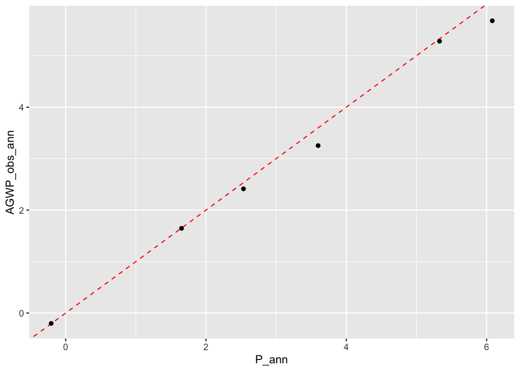

```r
ggplot(prod_all, aes(x = P_ann, y = AGWP_obs_ann)) + geom_abline(linetype = 2,
    colour = "red") + geom_point()
```

# References

Kohyama, Takashi S., Tetsuo I. Kohyama, and Douglas Sheil. 2018. “Definition and Estimation of Vital Rates from Repeated Censuses: Choices, Comparisons and Bias Corrections Focusing on Trees.” Edited by Mark Rees. *Methods in Ecology and Evolution* 9 (4): 809–21. https://doi.org/10.1111/2041-210x.12929.

———. 2019. “Estimating Net Biomass Production and Loss from Repeated Measurements of Trees in Forests and Woodlands: Formulae, Biases and Recommendations.” *Forest Ecology and Management* 433 (February): 729–40. https://doi.org/10.1016/j.foreco.2018.11.010.

Talbot, Joey, Simon L. Lewis, Gabriela Lopez-Gonzalez, Roel J. W. Brienen, Abel Monteagudo, Timothy R. Baker, Ted R. Feldpausch, et al. 2014. “Methods to Estimate Aboveground Wood Productivity from Long-Term Forest Inventory Plots.” *Forest Ecology and Management* 320: 30–38. https://doi.org/10.1016/j.foreco.2014.02.021.